# Final Project STAT-615

Maxwell Miller-Golub

2024-12-08

```r
# Set current working directory to same folder that houses data file if you haven't done so already.

local_filename <- "Salary Prediction of Data Professions.csv"

Salary_Prediction_of_Data_Professions <- read_csv(local_filename)
view(Salary_Prediction_of_Data_Professions)
```

# 1 Petro’s Section

## 1.1

Offer a preliminary description of the data set. For example, indicate the size of the data source, describe the variables, and include any other data profile information that would be of interest.

## 1.2

Generate relevant data visual plots that explore multicollinearity for the quantitative variables and normality for the quantitative variables as well. Also, use R code to confirm the levels of the categorical variables.

## 1.3

Using R code, produce a full Regression Model that consists of quantitative and categorical variables. Make use of the R generated dummy variable matrices

# 2 Max’s Section

## 2.1

Using only the quantitative variables as predictors, produce a model using matrix methods. Also use matrix methods to find the fitted values and the residuals

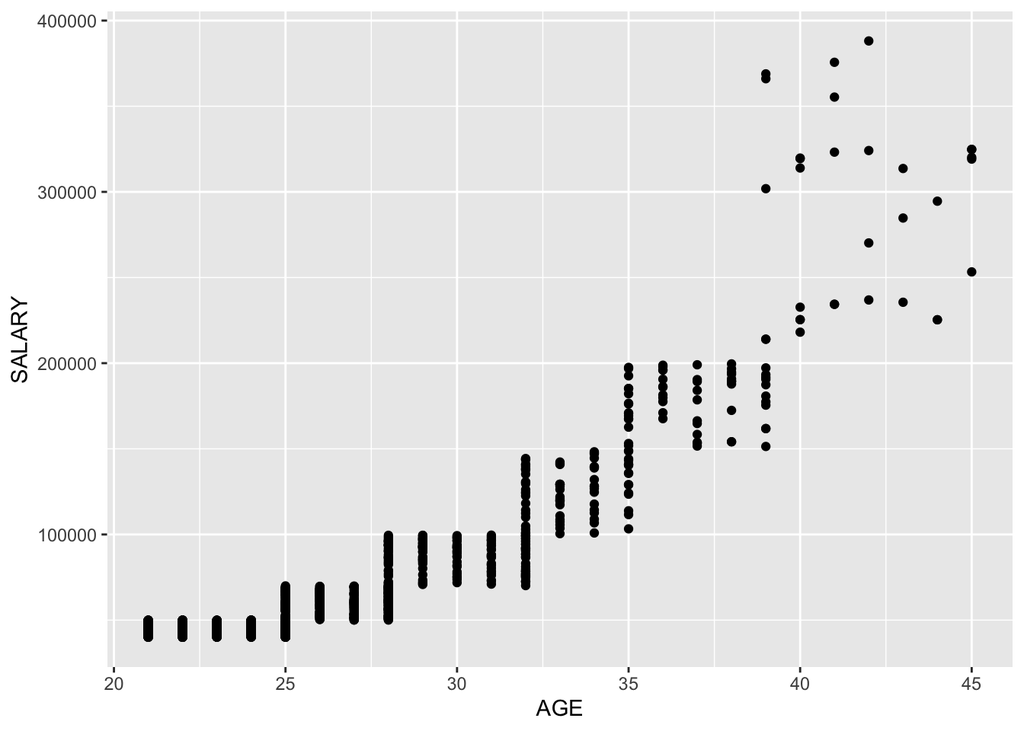

```r
# Finding a subsection of the data that is solely quantitative

quantative_model <- Salary_Prediction_of_Data_Professions %>%
  select(SALARY, AGE, `PAST EXP`, `LEAVES USED`)

# Eliminating cases with na values to prep for matrix

complete_dataset <- quantative_model[complete.cases(quantative_model),]

quant_model <- lm(SALARY ~ AGE + `PAST EXP` + `LEAVES USED`, data = complete_dataset)
quant_model2 <- lm(SALARY ~ AGE, data = complete_dataset)
#summary(quant_model)
#x <- complete_dataset$AGE
#y <- complete_dataset$SALARY

ggplot(complete_dataset)+
  geom_point(aes(AGE, SALARY))
```

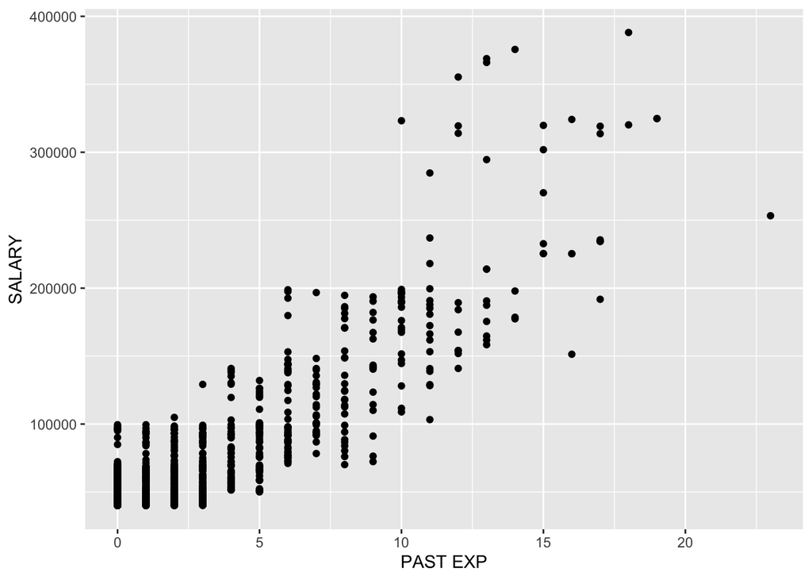

```r
ggplot(complete_dataset)+
  geom_point(aes(`PAST EXP`, SALARY))
```

```r
# Age has the highest t value so this is the predictor variable we will use with the matrices

# Creating a matrix for AGE (predictor) with a column of "1s"

quantitative_predictor_with_dummy <- complete_dataset %>%
  mutate(INTERCEPT = 1) %>%
  select(INTERCEPT, AGE)

x_matrix <- as.matrix(quantitative_predictor_with_dummy)
#head(x_matrix)

# Creating a matrix for the response variable

quantitative_response <- complete_dataset %>%
  select(SALARY)

y_matrix <- as.matrix(quantitative_response)
#head(y_matrix)

#t(x) -> Transpose of x
#%*% -> row column multiplication
#solve(x) -> inverse of x

# Find Slope and Intercept
solve(t(x_matrix)%*%x_matrix)%*%t(x_matrix)%*%y_matrix -> intercept_and_slope
intercept_and_slope
```

```
##                SALARY
## INTERCEPT -145608.896
## AGE          8229.989
```

```r
# Find Residual Values
residuals <- y_matrix -  x_matrix %*% intercept_and_slope
head(residuals)
```

```
##          SALARY
## [1,]  17349.127
## [2,]  13734.127
## [3,]  10099.138
## [4,]  13285.138
## [5,]   4888.138
## [6,] -21352.796
```

```r
# Find Fitted values
fitted <- x_matrix %*% intercept_and_slope
head(fitted)
```

```
##        SALARY
## [1,] 27220.87
## [2,] 27220.87
## [3,] 35450.86
## [4,] 35450.86
## [5,] 35450.86
## [6,] 84830.80
```

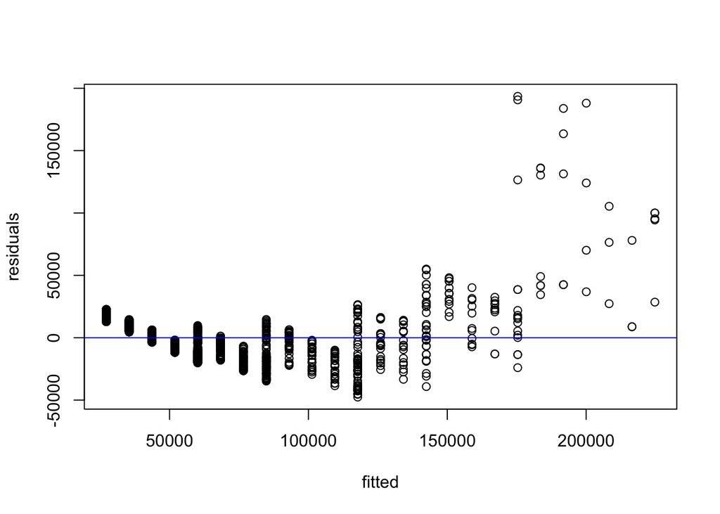

```r
plot(fitted, residuals)
abline(h = 0, col = "blue")
```

## 2.2

Produce an output summary table to be used to analyze and evaluate the full model (Adjusted R squared, Standard Error, Significance of Variables, ect…)

```r
full_model_prep <- Salary_Prediction_of_Data_Professions %>%
  select(SALARY, AGE, SEX, DESIGNATION, UNIT, `PAST EXP`, `LEAVES USED`, RATINGS)

full_model <- lm(SALARY ~ AGE + SEX + DESIGNATION + UNIT + `PAST EXP` + `LEAVES USED` + RATINGS, data = full_model_prep)
summary(full_model)
```

```
##
## Call:
## lm(formula = SALARY ~ AGE + SEX + DESIGNATION + UNIT + `PAST EXP` +
##     `LEAVES USED` + RATINGS, data = full_model_prep)
##
## Residuals:
##    Min     1Q Median     3Q    Max
## -72427  -2870    107   2974 101751
##
## Coefficients:
##                            Estimate Std. Error t value            Pr(>|t|)
## (Intercept)                40498.87    3410.93  11.873 <0.0000000000000002 ***
## AGE                          285.76     144.59   1.976              0.0482 *
## SEXM                        -258.34     308.58  -0.837              0.4026
## DESIGNATIONAssociate       41053.84    1027.78  39.944 <0.0000000000000002 ***
## DESIGNATIONDirector       240423.68    2579.58  93.203 <0.0000000000000002 ***
## DESIGNATIONManager         79945.26    1463.86  54.613 <0.0000000000000002 ***
## DESIGNATIONSenior Analyst  14100.68     622.68  22.645 <0.0000000000000002 ***
## DESIGNATIONSenior Manager 132513.89    1876.87  70.604 <0.0000000000000002 ***
## UNITIT                      -762.07     526.37  -1.448              0.1478
## UNITManagement              -355.37     536.14  -0.663              0.5075
## UNITMarketing               -235.16     532.68  -0.441              0.6589
## UNITOperations               -95.55     533.15  -0.179              0.8578
## UNITWeb                     -569.08     535.02  -1.064              0.2876
## `PAST EXP`                  -260.78     154.69  -1.686              0.0920 .
## `LEAVES USED`                -40.15      33.53  -1.197              0.2313
## RATINGS                     -146.19     138.56  -1.055              0.2915
## ---
## Signif. codes:  0 '***' 0.001 '**' 0.01 '*' 0.05 '.' 0.1 ' ' 1
##
## Residual standard error: 7897 on 2618 degrees of freedom
##   (5 observations deleted due to missingness)
## Multiple R-squared:  0.9543, Adjusted R-squared:  0.9541
## F-statistic:  3647 on 15 and 2618 DF,  p-value: < 0.00000000000000022
```

Age (p < 0.05) and Job Designation (p < 0.00001) are both statistically significant, indicating a very high probability that the change seen in the response (salary) is not due to chance alone.

## 2.3

Use procedures and techniques explored in class to produce confidence intervals for the independent quantitative variables of your model. Choose at least two of the quantitative variables to find confidence intervals for.

```r
# calculation t scores
qt(p = 0.025, df = 2632 , lower.tail = FALSE) -> t_score

# calculate Past Exp confidence intervals
past_exp_UB <- -260.78 + t_score*154.69
past_exp_LB <- -260.78 - t_score*154.69

# calculate Age confidence interval
age_UB <- 285.76 + t_score*144.59
age_LB <- 285.76 - t_score*144.59
```

# 3 Conie’s Section

## 3.1

Now produce a reduced model (removing variables of your choice with justification). Use R summary coding for both models and offer justification for choosing one model over the other.

```r
# review summary statistics of full model
summary(full_model)
```

```
##
## Call:
## lm(formula = SALARY ~ AGE + SEX + DESIGNATION + UNIT + `PAST EXP` +
##     `LEAVES USED` + RATINGS, data = full_model_prep)
##
## Residuals:
##    Min     1Q Median     3Q    Max
## -72427  -2870    107   2974 101751
##
## Coefficients:
##                            Estimate Std. Error t value            Pr(>|t|)
## (Intercept)                40498.87    3410.93  11.873 <0.0000000000000002 ***
## AGE                          285.76     144.59   1.976              0.0482 *
## SEXM                        -258.34     308.58  -0.837              0.4026
## DESIGNATIONAssociate       41053.84    1027.78  39.944 <0.0000000000000002 ***
## DESIGNATIONDirector       240423.68    2579.58  93.203 <0.0000000000000002 ***
## DESIGNATIONManager         79945.26    1463.86  54.613 <0.0000000000000002 ***
## DESIGNATIONSenior Analyst  14100.68     622.68  22.645 <0.0000000000000002 ***
## DESIGNATIONSenior Manager 132513.89    1876.87  70.604 <0.0000000000000002 ***
## UNITIT                      -762.07     526.37  -1.448              0.1478
## UNITManagement              -355.37     536.14  -0.663              0.5075
## UNITMarketing               -235.16     532.68  -0.441              0.6589
## UNITOperations               -95.55     533.15  -0.179              0.8578
## UNITWeb                     -569.08     535.02  -1.064              0.2876
## `PAST EXP`                  -260.78     154.69  -1.686              0.0920 .
## `LEAVES USED`                -40.15      33.53  -1.197              0.2313
## RATINGS                     -146.19     138.56  -1.055              0.2915
## ---
## Signif. codes:  0 '***' 0.001 '**' 0.01 '*' 0.05 '.' 0.1 ' ' 1
##
## Residual standard error: 7897 on 2618 degrees of freedom
##   (5 observations deleted due to missingness)
## Multiple R-squared:  0.9543, Adjusted R-squared:  0.9541
## F-statistic:  3647 on 15 and 2618 DF,  p-value: < 0.00000000000000022
```

```r
# build reduced model
reduced_model <- lm(SALARY ~ DESIGNATION + AGE, data = full_model_prep)

#review summary statistics of reduced model
summary(reduced_model)
```

```
##
## Call:
## lm(formula = SALARY ~ DESIGNATION + AGE, data = full_model_prep)
##
## Residuals:
##    Min     1Q Median     3Q    Max
## -72622  -2891    170   3059 101099
##
## Coefficients:
##                           Estimate Std. Error t value            Pr(>|t|)
## (Intercept)                41921.5     2590.0  16.186 <0.0000000000000002 ***
## DESIGNATIONAssociate       41228.8     1018.6  40.477 <0.0000000000000002 ***
## DESIGNATIONDirector       239429.9     2526.1  94.784 <0.0000000000000002 ***
## DESIGNATIONManager         79862.5     1461.7  54.636 <0.0000000000000002 ***
## DESIGNATIONSenior Analyst  14417.7      595.3  24.221 <0.0000000000000002 ***
## DESIGNATIONSenior Manager 131781.0     1854.3  71.067 <0.0000000000000002 ***
## AGE                          134.8      112.3   1.201                0.23
## ---
## Signif. codes:  0 '***' 0.001 '**' 0.01 '*' 0.05 '.' 0.1 ' ' 1
##
## Residual standard error: 7902 on 2629 degrees of freedom
##   (3 observations deleted due to missingness)
## Multiple R-squared:  0.9542, Adjusted R-squared:  0.9541
## F-statistic:  9133 on 6 and 2629 DF,  p-value: < 0.00000000000000022
```

```r
# confirm with stepwise regression
sw_intercept <- lm(SALARY ~ 1, data = full_model_prep)
sw_intercept
```

```
##
## Call:
## lm(formula = SALARY ~ 1, data = full_model_prep)
##
## Coefficients:
## (Intercept)
##       58137
```

```r
sw_all <- full_model

sw_forward <- step(sw_intercept, direction = 'forward', scope = formula(sw_all), trace = 0)
sw_forward$anova
```

| Step | Df | Deviance | Resid. Df | Resid. Dev | AIC |
| --- | --- | --- | --- | --- | --- |
|  | NA | NA | 2638 | 3587442457162 | 55500.98 |
| + DESIGNATION | -5 | 3423152172706 | 2633 | 164290284456 | 47373.46 |

```r
#final reduced model
final_reduced_model <- lm(SALARY ~ DESIGNATION, data = full_model_prep)
summary(final_reduced_model)
```

```
##
## Call:
## lm(formula = SALARY ~ DESIGNATION, data = full_model_prep)
##
## Residuals:
##    Min     1Q Median     3Q    Max
## -72984  -2913    132   3034 101141
##
## Coefficients:
##                           Estimate Std. Error t value            Pr(>|t|)
## (Intercept)                45020.1      178.9  251.61 <0.0000000000000002 ***
## DESIGNATIONAssociate       42182.9      651.5   64.75 <0.0000000000000002 ***
## DESIGNATIONDirector       241951.1     1407.8  171.86 <0.0000000000000002 ***
## DESIGNATIONManager         81252.5      895.7   90.71 <0.0000000000000002 ***
## DESIGNATIONSenior Analyst  14881.2      455.3   32.69 <0.0000000000000002 ***
## DESIGNATIONSenior Manager 133644.2     1019.0  131.15 <0.0000000000000002 ***
## ---
## Signif. codes:  0 '***' 0.001 '**' 0.01 '*' 0.05 '.' 0.1 ' ' 1
##
## Residual standard error: 7899 on 2633 degrees of freedom
## Multiple R-squared:  0.9542, Adjusted R-squared:  0.9541
## F-statistic: 1.097e+04 on 5 and 2633 DF,  p-value: < 0.00000000000000022
```

```r
final_reduced_model
```

```
##
## Call:
## lm(formula = SALARY ~ DESIGNATION, data = full_model_prep)
##
## Coefficients:
##               (Intercept)       DESIGNATIONAssociate
##                     45020                      42183
##       DESIGNATIONDirector         DESIGNATIONManager
##                    241951                      81252
## DESIGNATIONSenior Analyst  DESIGNATIONSenior Manager
##                     14881                     133644
```

After reviewing the summary statistics of the full model, we can remove the variables Unit, Past Exp, Leaves Used, and Sex because none are statistically significant. For all variables, p > 0.05. We can reduce the model to include only Age and Designation, who are significant because p < 0.05 in the full model. After reducing the model, we see that the only significant variable is Designation - Age now has p > 0.05. After running a stepwise regression to confirm the outputs, our final reduced model only includes the indicator variable Designation.

## 3.2

Research and apply a model analysis technique not discussed in class to your full model or reduced model. Fully explain the technique or procedure and how it is being applied to your specific model.

```r
# Remove rows with missing values
data_cleaned <- na.omit(full_model_prep[c("AGE", "SALARY", "DESIGNATION", "LEAVES USED", "RATINGS", "PAST EXP",
                                          "RATINGS", "UNIT")])

data_cleaned$DESIGNATION <- as.factor(data_cleaned$DESIGNATION)
data_cleaned$UNIT <- as.factor(data_cleaned$UNIT)

# Fit a polynomial regression model (degree = 2)
polymodel <- lm(SALARY ~ poly(AGE, 2) + DESIGNATION +  poly(UNIT, 2) + poly(`PAST EXP`, 2) +
                  poly(`LEAVES USED`, 2) + poly(RATINGS, 2), data = data_cleaned)
summary(polymodel)
```

```
##
## Call:
## lm(formula = SALARY ~ poly(AGE, 2) + DESIGNATION + poly(UNIT,
##     2) + poly(`PAST EXP`, 2) + poly(`LEAVES USED`, 2) + poly(RATINGS,
##     2), data = data_cleaned)
##
## Residuals:
##    Min     1Q Median     3Q    Max
## -69560  -2886    146   3004 104888
##
## Coefficients:
##                           Estimate Std. Error t value             Pr(>|t|)
## (Intercept)                45687.1      296.9 153.898 < 0.0000000000000002 ***
## poly(AGE, 2)1             145364.6    38749.7   3.751             0.000180 ***
## poly(AGE, 2)2              78487.5    20898.6   3.756             0.000177 ***
## DESIGNATIONAssociate       39848.2     1079.8  36.904 < 0.0000000000000002 ***
## DESIGNATIONDirector       230465.8     4444.1  51.859 < 0.0000000000000002 ***
## DESIGNATIONManager         76825.0     1719.6  44.676 < 0.0000000000000002 ***
## DESIGNATIONSenior Analyst  14260.5      624.6  22.830 < 0.0000000000000002 ***
## DESIGNATIONSenior Manager 126798.1     2601.0  48.750 < 0.0000000000000002 ***
## poly(UNIT, 2)1             -2195.7     7895.4  -0.278             0.780960
## poly(UNIT, 2)2               553.3     7892.4   0.070             0.944113
## poly(`PAST EXP`, 2)1      -66923.2    23118.5  -2.895             0.003826 **
## poly(`PAST EXP`, 2)2      -35080.0    13555.0  -2.588             0.009707 **
## poly(`LEAVES USED`, 2)1    -8343.1     7893.7  -1.057             0.290643
## poly(`LEAVES USED`, 2)2    -6417.9     7911.3  -0.811             0.417308
## poly(RATINGS, 2)1          -9029.6     7911.1  -1.141             0.253818
## poly(RATINGS, 2)2          -8423.3     7888.8  -1.068             0.285729
## ---
## Signif. codes:  0 '***' 0.001 '**' 0.01 '*' 0.05 '.' 0.1 ' ' 1
##
## Residual standard error: 7878 on 2618 degrees of freedom
## Multiple R-squared:  0.9546, Adjusted R-squared:  0.9543
## F-statistic:  3666 on 15 and 2618 DF,  p-value: < 0.00000000000000022
```

```r
# perform a stepwise regression with the polynomial model
sw_poly_intercept <- lm(SALARY ~ 1, data = data_cleaned)
sw_poly_forward <- step(sw_poly_intercept, direction = 'forward', scope = formula(polymodel), trace = 0)
sw_poly_forward$anova
```

| Step | Df | Deviance | Resid. Df | Resid. Dev | AIC |
| --- | --- | --- | --- | --- | --- |
|  | NA | NA | 2633 | 3575240225156 | 55391.84 |
| + DESIGNATION | -5 | 3411313403909 | 2628 | 163926821247 | 47282.89 |
| + poly(AGE, 2) | -2 | 436979347 | 2626 | 163489841900 | 47279.86 |
| + poly(`PAST EXP`, 2) | -2 | 733348442 | 2624 | 162756493458 | 47272.02 |

```r
# build a final reduced model and review summary statistics
final_polymodel <- lm(SALARY ~ DESIGNATION + poly(AGE, 2) + poly (`PAST EXP`, 2), data = data_cleaned)
final_polymodel
```

```
##
## Call:
## lm(formula = SALARY ~ DESIGNATION + poly(AGE, 2) + poly(`PAST EXP`,
##     2), data = data_cleaned)
##
## Coefficients:
##               (Intercept)       DESIGNATIONAssociate
##                     45682                      39859
##       DESIGNATIONDirector         DESIGNATIONManager
##                    230544                      76846
## DESIGNATIONSenior Analyst  DESIGNATIONSenior Manager
##                     14265                     126911
##             poly(AGE, 2)1              poly(AGE, 2)2
##                    144810                      78420
##      poly(`PAST EXP`, 2)1       poly(`PAST EXP`, 2)2
##                    -67592                     -35034
```

```r
summary(final_polymodel)
```

```
##
## Call:
## lm(formula = SALARY ~ DESIGNATION + poly(AGE, 2) + poly(`PAST EXP`,
##     2), data = data_cleaned)
##
## Residuals:
##    Min     1Q Median     3Q    Max
## -69904  -2916     96   3028 104835
##
## Coefficients:
##                           Estimate Std. Error t value             Pr(>|t|)
## (Intercept)                45681.7      296.5 154.085 < 0.0000000000000002 ***
## DESIGNATIONAssociate       39858.6     1077.0  37.008 < 0.0000000000000002 ***
## DESIGNATIONDirector       230543.7     4439.6  51.929 < 0.0000000000000002 ***
## DESIGNATIONManager         76846.2     1716.0  44.781 < 0.0000000000000002 ***
## DESIGNATIONSenior Analyst  14264.7      624.1  22.856 < 0.0000000000000002 ***
## DESIGNATIONSenior Manager 126911.3     2596.8  48.873 < 0.0000000000000002 ***
## poly(AGE, 2)1             144809.8    38688.1   3.743             0.000186 ***
## poly(AGE, 2)2              78420.2    20881.6   3.755             0.000177 ***
## poly(`PAST EXP`, 2)1      -67591.9    23078.1  -2.929             0.003432 **
## poly(`PAST EXP`, 2)2      -35033.6    13535.9  -2.588             0.009701 **
## ---
## Signif. codes:  0 '***' 0.001 '**' 0.01 '*' 0.05 '.' 0.1 ' ' 1
##
## Residual standard error: 7876 on 2624 degrees of freedom
## Multiple R-squared:  0.9545, Adjusted R-squared:  0.9543
## F-statistic:  6113 on 9 and 2624 DF,  p-value: < 0.00000000000000022
```

Polynomial Model

y = B0 + (B1 * DESIGNATION) + (B2 * AGE) + (B3 * AGE)^2 + (B4 * PAST EXP) + (B5 * PAST EXP)^2 + e

## 3.3

Offer final summary perspectives about the data and the models that you produce, suggesting how your models or model analysis enhanced your understanding of the data. (4 or 5 sentences)

Our Changing Perspectives

Our first full model gives us a wide view of the data and includes a number of variables that we would conventionally associate with salary, like Age, Sex, Past Experience, Designation. After analyzing the summary statistics of the data, we can see that most of these variables are not statistically significant to predicting the salaries of data science professionals from this data set. Even after keeping the statistically significant variables, our reduced model proved to eliminate further variables, leaving only Designation as a statistically significant predictor of salary. Using a polynomial model allowed us to better fit a model to the data that we had available, accounting for some of the nonlinear trends. This is more of what we expected to see from the beginning of the project, but something that may not be easily captured in a strictly linear relationship.

What does this mean?

This means that our data set is potentially too narrow. Even though we have over 2600 entries, this may not be a large enough sample size to overcome the effects of the designation variable. In a deeper investigation, we may need to gather data from other sources to see if the Designation (which we may term as any sort of job level variable) is a powerful indicator across the board in this industry, or if this is a result of our data selection.